# Child poverty and Year 6 obesity

HPDM182

## Research question

This study sets out to answer the question: In 2024/25, was obesity among Year 6 children more common in English council areas with higher rates of child poverty?

Our hypothesis was that council areas with higher child poverty rates would also have higher Year 6 obesity rates.

The null hypothesis was that there was no link between child poverty rates and Year 6 obesity rates across council areas.

We conducted a literature review, identified suitable datasets, explored these datasets including with visualsations, and then performed statistical analysis to try to answer the research question.

We then evaluate our findings, including limitations, possible impact, and areas for further research.

## Background

Socioeconomic inequalities in childhood obesity in England were documented in data from the late 1990s and early 2000s (Stamatakis et al., 2005). Subsequent research found that severe obesity was more prevalent among children living in more deprived areas (Ells et al., 2015). The National Child Measurement Programme (NCMP) reported a sharp increase in childhood obesity prevalence in 2020/21, during the COVID-19 pandemic (NCMP, 2021).

Several factors may contribute to this socioeconomic gradient. The cost and availability of healthier food can shape what families are able to buy (Eskandari et al., 2022), while lower levels of physical activity may also play a role (Cheung et al., 2022). Family stress and parental perceptions of children’s weight have also been explored as potential influences (Broadbent et al., 2024). Against this background, our study examines whether English local authorities with higher rates of child poverty also had higher Year 6 obesity prevalence in 2024/25.

## Datasets

We used two sets of official statistics to compare child poverty and Year 6 obesity across English council areas in 2024/25.

### Year 6 obesity

This dataset shows the percentage of children aged 10–11 who were classified as living with obesity, including severe obesity. The figures come from height and weight measurements taken in mainstream state-funded schools as part of the National Child Measurement Programme.

The programme uses standard measurement procedures, which helps make the figures comparable across councils. Participation can vary, and where fewer eligible children are measured, the figure may be less representative of the area.

We downloaded the 2024/25 CSV for Year 6 prevalence of obesity (including severe obesity) from the Fingertips Compare areas view on 9th November 2026. The original CSV, Year_6_prevalence_of_obesity_compare_areas_2024_2025.csv, is saved in the same folder as index.Rmd. [View the source data from OHID Fingertips (indicator 90323)](https://fingertips.phe.org.uk/profile/obesity-physical-activity-nutrition/) [View the programme’s methods and quality notes](https://www.gov.uk/government/statistics/national-child-measurement-programme-ncmp-annual-report-academic-year-2024-to-2025-england)

### Child poverty

This dataset estimates the percentage of children under 16 living in relative low-income families in the financial year ending March 2025. Relative low income means income below 60% of the UK median, after allowing for family size and before deducting housing costs.

The Department for Work and Pensions uses benefits and earnings records to produce local estimates using a common method. This makes it possible to compare council areas. The estimates rely in part on benefit claims, so some low-income families may be missed. Housing costs also vary between areas, and are not considered in this measure.

We downloaded the 2024/25 CSV for children in relative poverty before housing costs from the ONS Explore Local Statistics Compare areas view on 9 November 2026. The data come from the Department for Work and Pensions and cover the financial year ending March 2025. The original CSV, children-in-relative-poverty-before-housing_compare_areas_2024_2025.csv, is saved in the same folder as index.Rmd.

[View the source data from ONS Explore Local Statistics](https://www.ons.gov.uk/explore-local-statistics/indicators/children-in-relative-poverty-before-housing) View the DWP methods and quality notes

### How we used the two datasets

We matched the two datasets using official codes for English council areas. We checked for duplicate codes and missing values.

The obesity figures cover the 2024/25 academic year. The poverty figures cover the financial year ending March 2025. These periods overlap, but they start and end at different times.

The poverty figures cover all children under 16, while the obesity figures cover Year 6 children aged 10–11.

So the comparison is of overall child poverty in each council area in the financial year, with obesity in its Year 6 population in the academic year.

### Read and inspect the CSV files

```r
obesity_file <- "Year_6_prevalence_of_obesity_compare_areas_2024_2025.csv"
poverty_file <- "children-in-relative-poverty-before-housing_compare_areas_2024_2025.csv"

missing_files <- c(obesity_file, poverty_file)
missing_files <- missing_files[!file.exists(missing_files)]
if (length(missing_files) > 0) {
  stop("Put these CSV files in the same folder as index.Rmd: ",
       paste(missing_files, collapse = ", "))
}

obesity_raw <- read.csv(obesity_file, fileEncoding = "UTF-8-BOM",
                       na.strings = c("", "NA"), stringsAsFactors = FALSE)
poverty_raw <- read.csv(poverty_file, fileEncoding = "UTF-8-BOM",
                       na.strings = c("", "NA"), stringsAsFactors = FALSE)

data.frame(file = c(obesity_file, poverty_file),
           rows = c(nrow(obesity_raw), nrow(poverty_raw)),
           columns = c(ncol(obesity_raw), ncol(poverty_raw)))
```

```
##                                                                      file rows
## 1                Year_6_prevalence_of_obesity_compare_areas_2024_2025.csv  297
## 2 children-in-relative-poverty-before-housing_compare_areas_2024_2025.csv  364
##   columns
## 1      27
## 2       4
```

```r
names(obesity_raw)
```

```
##  [1] "Indicator.ID"
##  [2] "Indicator.Name"
##  [3] "Parent.Code"
##  [4] "Parent.Name"
##  [5] "Area.Code"
##  [6] "AreaName"
##  [7] "Area.Type"
##  [8] "Sex"
##  [9] "Age"
## [10] "Category.Type"
## [11] "Category"
## [12] "Time.period"
## [13] "Value"
## [14] "Lower.CI.95.0.limit"
## [15] "Upper.CI.95.0.limit"
## [16] "Lower.CI.99.8.limit"
## [17] "Upper.CI.99.8.limit"
## [18] "Count"
## [19] "Denominator"
## [20] "Value.note"
## [21] "Recent.Trend"
## [22] "Compared.to.England.value.or.percentiles"
## [23] "Compared.to.parent.value.or.percentiles"
## [24] "Time.period.Sortable"
## [25] "New.data"
## [26] "Compared.to.goal"
## [27] "Time.period.range"
```

```r
names(poverty_raw)
```

```
## [1] "areacd" "areanm" "period" "value"
```

```r
head(obesity_raw[c("Area.Code", "AreaName", "Area.Type", "Time.period", "Value")])
```

```
##   Area.Code      AreaName                                Area.Type Time.period
## 1 E92000001       England                                  England     2024/25
## 2 E08000028      Sandwell Lower tier local authorities (post 4/23)     2024/25
## 3 E08000011      Knowsley Lower tier local authorities (post 4/23)     2024/25
## 4 E08000031 Wolverhampton Lower tier local authorities (post 4/23)     2024/25
## 5 E09000028     Southwark Lower tier local authorities (post 4/23)     2024/25
## 6 E07000136        Boston Lower tier local authorities (post 4/23)     2024/25
##      Value
## 1 22.24756
## 2 30.67690
## 3 30.05620
## 4 29.98620
## 5 29.67250
## 6 29.09090
```

```r
head(poverty_raw)
```

```
##      areacd               areanm         period    value
## 1 E06000001           Hartlepool 2024-04-01/P1Y 27.18399
## 2 E06000002        Middlesbrough 2024-04-01/P1Y 34.35237
## 3 E06000003 Redcar and Cleveland 2024-04-01/P1Y 26.23290
## 4 E06000004     Stockton-on-Tees 2024-04-01/P1Y 22.25529
## 5 E06000005           Darlington 2024-04-01/P1Y 24.79042
## 6 E06000006               Halton 2024-04-01/P1Y 23.03207
```

```r
table(obesity_raw$Area.Type, useNA = "ifany")
```

```
##
##                                  England
##                                        1
## Lower tier local authorities (post 4/23)
##                                      296
```

```r
table(obesity_raw$Time.period, useNA = "ifany")
```

```
##
## 2024/25
##     297
```

```r
table(poverty_raw$period, useNA = "ifany")
```

```
##
## 2024-04-01/P1Y
##            364
```

### Filter and inspect obesity prevalence before joining

The raw obesity dataset is filtered for year 2024/2025, age 10-11, and area type (lower tier local authorities).

The filtered obesity dataset contains 296 observations of 3 variables.

We can see that 2 local authorities do not have obesity data: City of London and Isles of Scilly. These are excluded from the analysis.

```r
obesity <- subset(
  obesity_raw,
  Indicator.ID == 90323 & Time.period == "2024/25" &
    Sex == "Persons" & Age == "10-11 yrs" &
    Area.Type == "Lower tier local authorities (post 4/23)",
  select = c(Area.Code, AreaName, Value)
)
names(obesity) <- c("authority_code", "authority", "obesity_pct")
obesity <- obesity[order(obesity$authority_code), ]
obesity$obesity_pct <- as.numeric(obesity$obesity_pct)

summary(obesity$obesity_pct)
```

```
##    Min. 1st Qu.  Median    Mean 3rd Qu.    Max.     NAs
##   9.701  18.275  21.491  21.249  24.453  30.677       2
```

```r
obesity[is.na(obesity$obesity_pct), ]
```

```
##     authority_code       authority obesity_pct
## 297      E06000053 Isles of Scilly          NA
## 296      E09000001  City of London          NA
```

An initial plot lets us see the spread of obesity rates. The horizontal position is simply the order of the local authority codes. We can see that there is considerable variation in obesity rates between areas, from around 10% to around 30%.

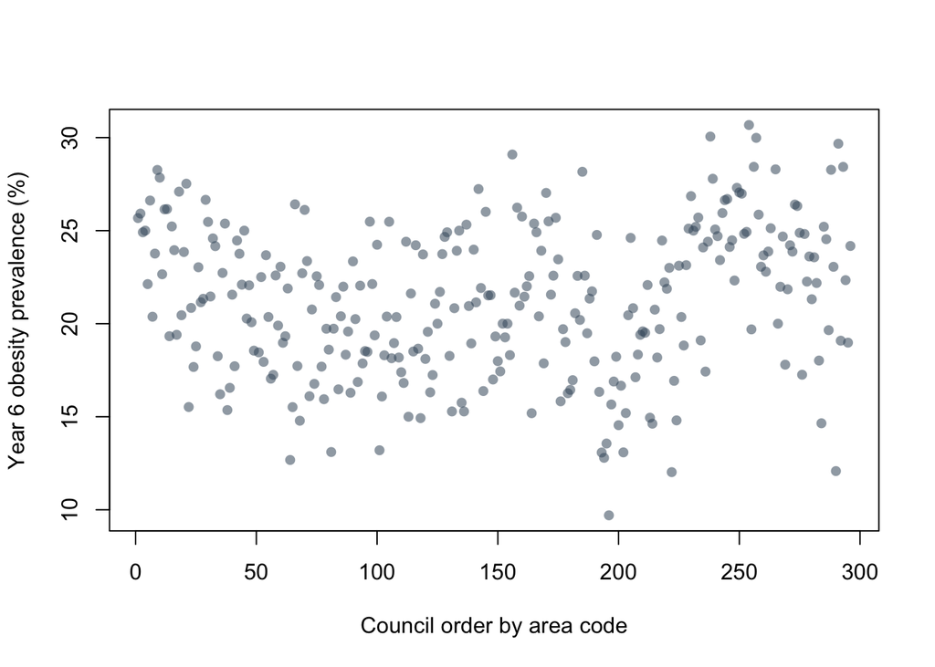

```r
point_colour <- adjustcolor("#42586A", alpha.f = 0.55)
plot(seq_len(nrow(obesity)), obesity$obesity_pct,
     xlab = "Council order by area code", ylab = "Year 6 obesity prevalence (%)",
     pch = 16, col = point_colour)
```

We can also inspect the data using a choropleth map. This draws each council area using GeoJSON data from the [ONS May 2023 local authority district boundaries](https://ckan.publishing.service.gov.uk/dataset/local-authority-districts-may-2023-boundaries-uk-bgc1/resource/3464ffbe-8b4f-441d-b5a5-5e16d2a065ad) page. This csv file has been downloaded and is saved in the working directory as lad_may_2023.geojson.

```r
library(sf)
```

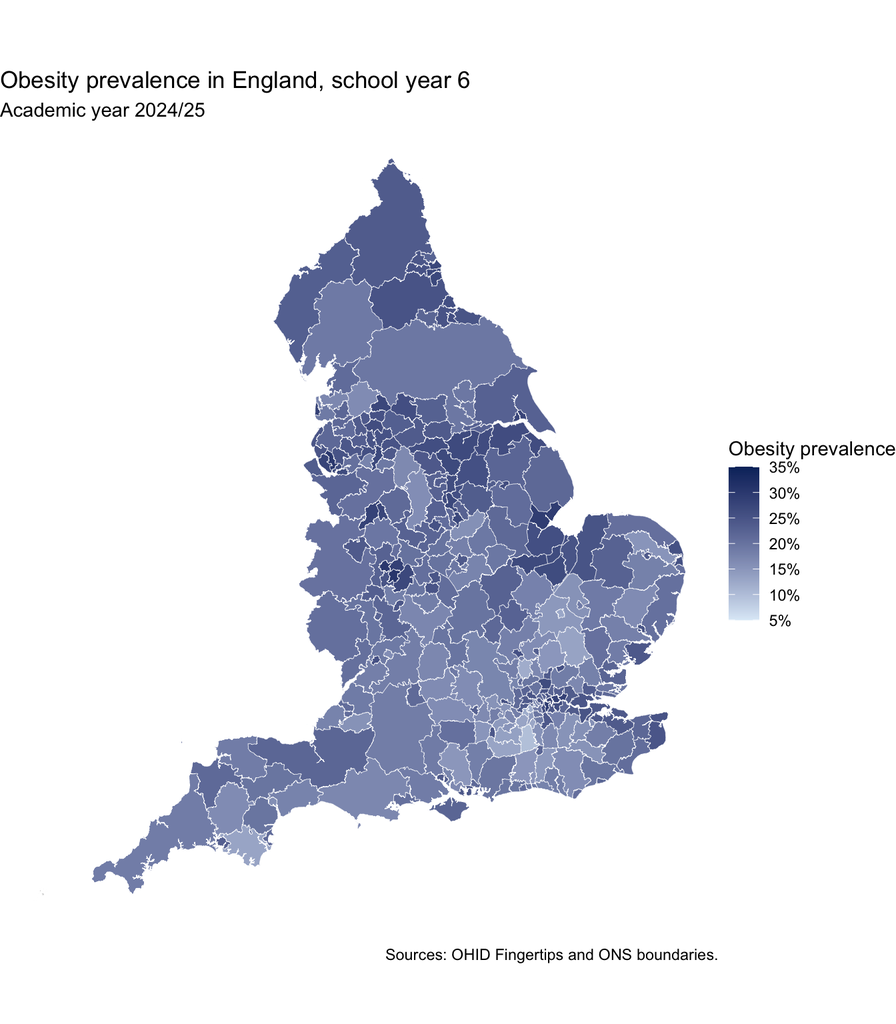

```r
library(ggplot2)
library(dplyr)
boundaries <- st_read("lad_may_2023.geojson", quiet = TRUE)
england <- filter(boundaries, startsWith(LAD23CD, "E"))

obesity_map <- left_join(
  england, obesity,
  by = c("LAD23CD" = "authority_code")
)

ggplot(obesity_map) +
  geom_sf(aes(fill = obesity_pct), colour = "white", linewidth = 0.1) +
  scale_fill_gradient(
    low = "#DEEBF7",
    high = "#08306B",
    limits = c(5, 35),
    breaks = seq(5, 35, by = 5),
    labels = function(x) paste0(x, "%"),
    oob = scales::squish,
    na.value = "grey85",
    name = "Obesity prevalence"
  ) +
  labs(
    title = "Obesity prevalence in England, school year 6",
    subtitle = "Academic year 2024/25",
    caption = "Sources: OHID Fingertips and ONS boundaries."
  ) +
  theme_void()
```

### Filter the poverty data to England

The raw poverty dataset covers the whole of the UK. The first letter `E` identifies English area codes. We select the financial year starting 1 April 2024. The join below then selects the codes that appear in the lower-tier obesity table.

```r
table(substr(poverty_raw$areacd, 1, 1), useNA = "ifany")
```

```
##
##   E   K   N   S   W
## 298   1  11  32  22
```

```r
poverty_england <- subset(
  poverty_raw, startsWith(areacd, "E") & period == "2024-04-01/P1Y",
  select = c(areacd, areanm, value)
)
names(poverty_england) <- c("authority_code", "poverty_area", "poverty_pct")
poverty_england$poverty_pct <- as.numeric(poverty_england$poverty_pct)

nrow(poverty_england)
```

```
## [1] 298
```

```r
head(poverty_england)
```

```
##   authority_code         poverty_area poverty_pct
## 1      E06000001           Hartlepool    27.18399
## 2      E06000002        Middlesbrough    34.35237
## 3      E06000003 Redcar and Cleveland    26.23290
## 4      E06000004     Stockton-on-Tees    22.25529
## 5      E06000005           Darlington    24.79042
## 6      E06000006               Halton    23.03207
```

```r
summary(poverty_england$poverty_pct)
```

```
##    Min. 1st Qu.  Median    Mean 3rd Qu.    Max.
##   5.175  12.609  16.696  18.046  22.286  40.553
```

Again, an initial plot lets us see the spread of poverty rates. The horizontal position is again the order of the local authority codes. We can see that there is again considerable variation in child poverty rates between areas, from around 5% to around 40%.

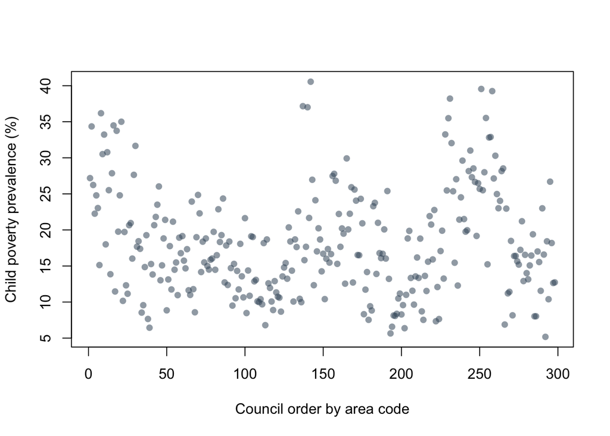

```r
point_colour <- adjustcolor("#42586A", alpha.f = 0.55)
plot(seq_len(nrow(poverty_england)), poverty_england$poverty_pct,
     xlab = "Council order by area code", ylab = "Child poverty prevalence (%)",
     pch = 16, col = point_colour)
```

Here is a similar choropleth map allowing visualisation of the spread of child poverty across local authority araes in England:

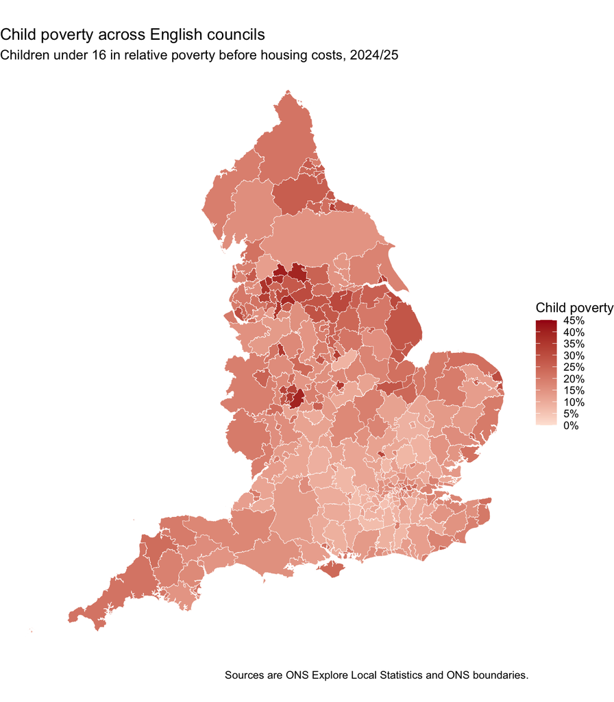

```r
poverty_map <- left_join(
  england, poverty_england,
  by = c("LAD23CD" = "authority_code")
)

ggplot(poverty_map) +
  geom_sf(aes(fill = poverty_pct), colour = "white", linewidth = 0.1) +
  scale_fill_gradient(
    low = "#FEE5D9",
    high = "#A50F15",
    limits = c(0, 45),
    breaks = seq(0, 45, by = 5),
    labels = function(x) paste0(x, "%"),
    oob = scales::squish,
    na.value = "grey85",
    name = "Child poverty"
  ) +
  labs(
    title = "Child poverty across English councils",
    subtitle = "Children under 16 in relative poverty before housing costs, 2024/25",
    caption = "Sources are ONS Explore Local Statistics and ONS boundaries."
  ) +
  theme_void()
```

### Join the tables and check the match

We keep every council from the obesity table. Joining on the official area code lets us see any missing matches, before excluding the rows with missing values.

```r
stopifnot(anyDuplicated(obesity$authority_code) == 0L,
          anyDuplicated(poverty_england$authority_code) == 0L)

join_table <- merge(obesity, poverty_england,
                    by = "authority_code", all.x = TRUE)
complete <- complete.cases(join_table[c("obesity_pct", "poverty_pct")])
analysis <- join_table[complete, ]

head(join_table)
```

```
##   authority_code            authority obesity_pct         poverty_area
## 1      E06000001           Hartlepool     25.6757           Hartlepool
## 2      E06000002        Middlesbrough     25.9162        Middlesbrough
## 3      E06000003 Redcar and Cleveland     24.9123 Redcar and Cleveland
## 4      E06000004     Stockton-on-Tees     25.0000     Stockton-on-Tees
## 5      E06000005           Darlington     22.1277           Darlington
## 6      E06000006               Halton     26.6187               Halton
##   poverty_pct
## 1    27.18399
## 2    34.35237
## 3    26.23290
## 4    22.25529
## 5    24.79042
## 6    23.03207
```

```r
data.frame(councils_in_join = nrow(join_table),
           matched_poverty_codes = sum(!is.na(join_table$poverty_area)),
           missing_obesity = sum(is.na(join_table$obesity_pct)),
           missing_poverty = sum(is.na(join_table$poverty_pct)),
           councils_in_analysis = nrow(analysis))
```

```
##   councils_in_join matched_poverty_codes missing_obesity missing_poverty
## 1              296                   296               2               0
##   councils_in_analysis
## 1                  294
```

```r
join_table[!complete, c("authority_code", "authority",
                        "obesity_pct", "poverty_pct")]
```

```
##     authority_code       authority obesity_pct poverty_pct
## 50       E06000053 Isles of Scilly          NA    8.852459
## 264      E09000001  City of London          NA    6.882022
```

## Exploratory analysis

The plot below shows how obesity prevalence varies across councils with different child poverty rates.

Each dot is an observation of poverty rate and obesity prevalance for a unique local authority area.

There is an initial impression of a positive relationship between obesity and poverty, as expected from the literature.

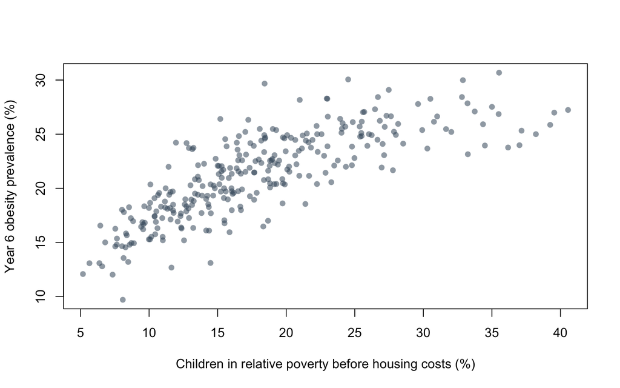

```r
x_label <- "Children in relative poverty before housing costs (%)"
y_label <- "Year 6 obesity prevalence (%)"
plot(obesity_pct ~ poverty_pct, data = analysis,
     xlab = x_label, ylab = y_label, pch = 16, col = point_colour)
```

## Statistical methods

### Fit a straight line

Ordinary least squares fits the line that minimises the sum of the squared gaps between observed and fitted obesity rates.

The slope gives the fitted difference in obesity prevalence per one percentage point difference in child poverty.

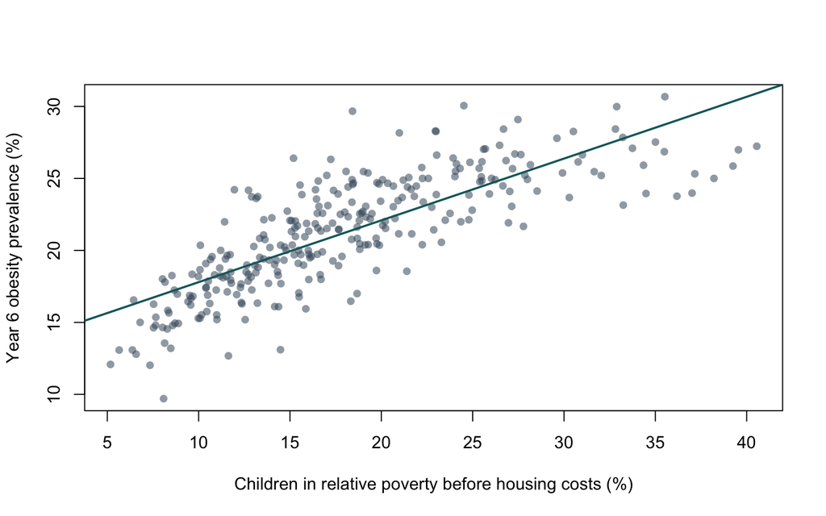

```r
model <- lm(obesity_pct ~ poverty_pct, data = analysis)
line_colour <- "#17686B"

plot(obesity_pct ~ poverty_pct, data = analysis,
     xlab = x_label, ylab = y_label, pch = 16, col = point_colour)
abline(model, col = line_colour, lwd = 2)
```

### Add 95% confidence intervals

The shaded band represents a 95% confidence interval for the mean fitted obesity rate at each poverty rate. It shows uncertainty around the line.

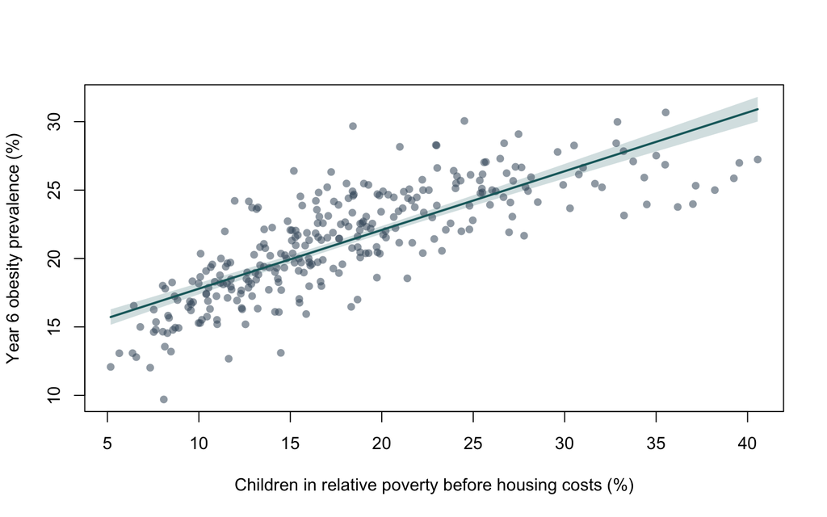

```r
poverty_grid <- data.frame(
  poverty_pct = seq(min(analysis$poverty_pct), max(analysis$poverty_pct),
                    length.out = 200)
)
band <- predict(model, newdata = poverty_grid, interval = "confidence",
                level = 0.95)

plot(obesity_pct ~ poverty_pct, data = analysis, type = "n",
     xlab = x_label, ylab = y_label,
     ylim = range(analysis$obesity_pct, band))
polygon(c(poverty_grid$poverty_pct, rev(poverty_grid$poverty_pct)),
        c(band[, "lwr"], rev(band[, "upr"])),
        col = adjustcolor(line_colour, alpha.f = 0.2), border = NA)
points(obesity_pct ~ poverty_pct, data = analysis, pch = 16,
       col = point_colour)
lines(poverty_grid$poverty_pct, band[, "fit"], col = line_colour, lwd = 2)
```

## Results

```r
pearson_r <- cor(analysis$poverty_pct, analysis$obesity_pct)
model_summary <- summary(model)
slope_10 <- 10 * coef(model)[["poverty_pct"]]
slope_ci_10 <- 10 * confint(model, "poverty_pct", level = 0.95)
format_2 <- function(x) sprintf("%.2f", x)

results <- data.frame(
  Measure = c("Councils", "Pearson correlation",
              "Slope per 10 percentage points higher child poverty",
              "95% confidence interval for that slope",
              "R-squared", "Residual standard deviation",
              "Residual variance"),
  Estimate = c(nobs(model), format_2(pearson_r),
               paste(format_2(slope_10), "percentage points"),
               paste(format_2(slope_ci_10[1]), "to",
                     format_2(slope_ci_10[2]), "percentage points"),
               format_2(model_summary$r.squared),
               paste(format_2(model_summary$sigma), "percentage points"),
               paste(format_2(model_summary$sigma^2),
                     "squared percentage points"))
)
knitr::kable(results, align = c("l", "l"))
```

| Measure | Estimate |
| --- | --- |
| Councils | 294 |
| Pearson correlation | 0.79 |
| Slope per 10 percentage points higher child poverty | 4.29 percentage points |
| 95% confidence interval for that slope | 3.91 to 4.67 percentage points |
| R-squared | 0.63 |
| Residual standard deviation | 2.43 percentage points |
| Residual variance | 5.93 squared percentage points |

In the straight-line model, a 10 percentage point higher child poverty rate across councils was associated with a 4.29 percentage point difference in fitted Year 6 obesity prevalence (95% CI 3.91 to 4.67). The estimate is unadjusted.

Pearson’s correlation describes the direction and strength of the straight-line relationship.

R-squared is the share of variation in obesity rates across councils accounted for by the fitted line. The residual standard deviation describes how far observed rates typically sit from the line. Residual variance is that standard deviation squared.

## Evaluation

The analysis used recent 2024/25 data and covered 294 English local authorities with data available for both child poverty and Year 6 obesity. Pearson’s correlation showed a strong positive association ($r = 0.79$). The linear regression described how obesity prevalence varied with child poverty and accounted for approximately 63% of the variation in Year 6 obesity prevalence across local authorities ($R^2 = 0.63$).

The cross-sectional ecological design limits what can be inferred. The association was measured at local-authority level, so it cannot tell us whether individual children living in poverty were more likely to have obesity or whether poverty caused the differences observed. Other factors, including ethnic composition, wider socioeconomic deprivation, physical activity and access to affordable healthy food, may also contribute to differences between areas. Local-authority averages may also mask inequalities within areas.

The two measures cover different populations and reporting periods. The poverty measure covers children under 16 in the financial year ending March 2025, while the obesity measure covers Year 6 pupils in the 2024/25 academic year. The National Child Measurement Programme also excludes some children, including those who are home educated or attend independent schools, which limits how well the estimates represent all children of Year 6 age.

Further research is needed to explore other contributing factors.

## Further research

A next step would be to compare the estimated association between child poverty and Year 6 obesity before and after accounting for region. This would show how much the estimate changes when differences between regions are taken into account.

A follow-up analysis could examine whether changes in child poverty between an earlier year and 2025 were associated with changes in Year 6 obesity prevalence over the same period. This would first require checking which local authorities had comparable boundaries and consistently defined measures in both years. It might give information about whether a relationship was getting weaker or stronger over time. However we could olnly identify data in this form from 2021/22 and so this limits the scope.

We noticed on visualisation of the scatterplot that a curve (like a banana) might fit the data better. A model that allows for a curved relationship could be compared with the linear model to assess whether the association differs across the observed range of child poverty rates.

## References

- Broadbent, P., Shen, Y., Pearce, A. and Katikireddi, S.V. (2024) ‘Trends in inequalities in childhood overweight and obesity prevalence: a repeat cross-sectional analysis of the Health Survey for England’, *Archives of Disease in Childhood*, 109(3), pp. 233–239. [DOI](https://doi.org/10.1136/archdischild-2023-325844)
- Ells, L.J., Hancock, C., Copley, V.R., Mead, E., Dinsdale, H., Kinra, S., Viner, R.M. and Rutter, H. (2015) ‘Prevalence of severe childhood obesity in England: 2006–2013’, *Archives of Disease in Childhood*, 100(7), pp. 631–636. [DOI](https://doi.org/10.1136/archdischild-2014-307036)
- Ernest, D.K. et al. (2025) ‘A scoping review of the social determinants of pediatric and adolescent obesity’, *International Journal of Pediatrics*, 2025, article 8871022. [DOI](https://doi.org/10.1155/ijpe/8871022)
- Eskandari, F., Lake, A.A., Rose, K., Butler, M. and O’Malley, C. (2022) ‘A mixed-method systematic review and meta-analysis of the influences of food environments and food insecurity on obesity in high-income countries’, *Food Science & Nutrition*, 10(11), pp. 3689–3723. [DOI](https://doi.org/10.1002/fsn3.2969)
- Office for Health Improvement and Disparities (2022) *Childhood obesity: applying All Our Health*. Updated 7 April 2022. [GOV.UK](https://www.gov.uk/government/publications/childhood-obesity-applying-all-our-health/childhood-obesity-applying-all-our-health) (Accessed: 18 November 2026).
- Office for Health Improvement and Disparities (2025a) *National Child Measurement Programme annual report, academic year 2024 to 2025, England*. [Report](https://www.gov.uk/government/statistics/national-child-measurement-programme-ncmp-annual-report-academic-year-2024-to-2025-england)
- Office for Health Improvement and Disparities (2025b) *Year 6 prevalence of obesity (including severe obesity), indicator 90323, academic year 2024/25*. Fingertips [CSV dataset]. [Source data](https://fingertips.phe.org.uk/profile/obesity-physical-activity-nutrition/) (Downloaded: 9 November 2026).
- Office for National Statistics (2026) *Children in relative poverty before housing costs, financial year ending March 2025*. Explore Local Statistics. Source data from the Department for Work and Pensions [CSV dataset]. [Source data](https://www.ons.gov.uk/explore-local-statistics/indicators/children-in-relative-poverty-before-housing) (Downloaded: 9 November 2026).
- Stamatakis, E., Primatesta, P., Chinn, S., Rona, R. and Falascheti, E. (2005) ‘Overweight and obesity trends from 1974 to 2003 in English children: what is the role of socioeconomic factors?’, *Archives of Disease in Childhood*, 90(10), pp. 999–1004. [DOI](https://doi.org/10.1136/adc.2004.068932)